# Data visualisation with ggplot2

Visualising data in R with ggplot2 package

Authors: **Mateusz Kuzak**, **Diana Marek**, **Hedi Peterson**

#### Disclaimer

We will here using functions of ggplot2 package. There are basic ploting capabilities in basic R, but ggplot2 adds more powerful plotting capabilities.

### Learning Objectives

> - Visualise some of the [mammals data](https://github.com/iDigBio/2015-09-23-TDWG-R-ecology/tree/gh-pages/data) from Figshare surveys.csv
> - Understand how to plot these data using R ggplot2 package. For more details on using ggplot2 see [official documentation](http://docs.ggplot2.org/current/).
> - Building step by step complex plots with ggplot2 package

Load required packages

```r
# plotting package
library(ggplot2)
# piping / chaining
library(magrittr)
# modern dataframe manipulations
library(dplyr)
```

```r
surveys_raw <- read.csv("data/surveys.csv")
```

`surveys.csv` data contains some measurements of the animals caught in plots.

## Data cleaning and preparing for plotting

Let’s look at the summary

```r
summary(surveys_raw)
```

There are few things we need to clean in the dataset.

There is missing species_id in some records. Let’s remove those.

```r
surveys <- surveys_raw %>%
           filter(species_id != "")
```

There are a lot of species with low counts, let’s remove the ones below 10 counts

```r
# count records per species
species_counts <- surveys %>%
                  group_by(species_id) %>%
                  tally

# get names of those frequent species
frequent_species <- species_counts %>%
                    filter(n >= 10) %>%
                    select(species_id)

surveys <- surveys %>%
           filter(species_id %in% frequent_species$species_id)
```

```r
surveys_weight_present <- surveys %>%
                      filter(!is.na(weight))
```

### Challenge

> - Do the same to remove rows without `hindfoot_length`. Save results in the new dataframe.

```r
surveys_length_present <- surveys %>%
                      filter(!is.na(hindfoot_length))
```

- How would you get the dataframe without missing values?

```r
surveys_complete <- surveys_weight_present %>%
                    filter(!is.na(hindfoot_length))
```

> We can chain filtering together using pipe operator (`%>%`) introduced earlier.

```r
surveys_complete <- surveys %>%
                    filter(!is.na(weight)) %>%
                    filter(!is.na(hindfoot_length))
```

> Make simple scatter plot of `hindfoot_length` (in millimeters) as a function of `weight` (in grams), using basic R plotting capabilities.

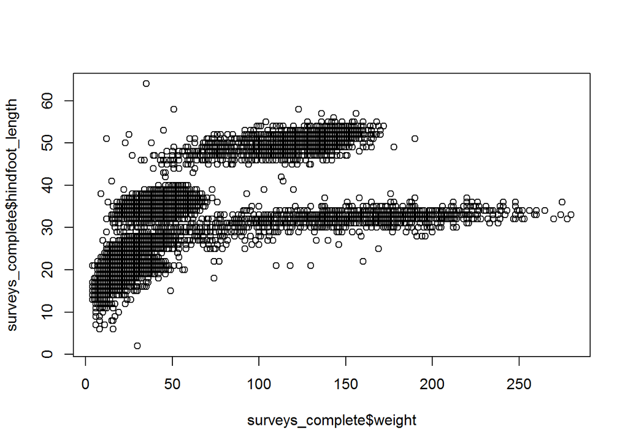

```r
plot(x=surveys_complete$weight, y=surveys_complete$hindfoot_length)
```

## Plotting with ggplot2

We will make the same plot using `ggplot2` package.

`ggplot2` is a plotting package that makes it sipmple to create complex plots from data in a dataframe. It uses default settings, which help creating publication quality plotts with minimal amount of settings and tweaking.

With ggplot graphics are build step by step by adding new elements.

To build a ggplot we need to:

- bind plot to a specific data frame

```r
ggplot(surveys_complete)
```

- define aestetics (`aes`), that maps variables in the data to axes on the plot or to plotting size, shape color, etc.,

```r
ggplot(surveys_complete, aes(x = weight, y = hindfoot_length))
```

- add `geoms` – graphical representation of the data in the plot (points, lines, bars). To add a geom to the plot use `+` operator:

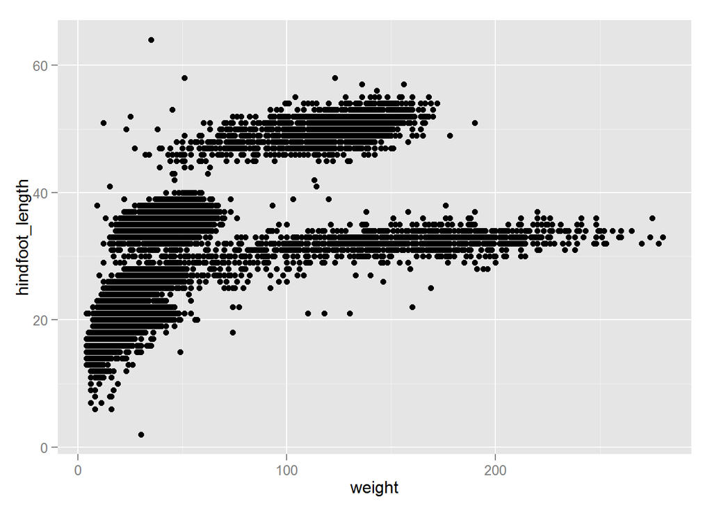

```r
ggplot(surveys_complete, aes(x = weight, y = hindfoot_length)) +
  geom_point()
```

## Modifying plots

- adding transparency (alpha)

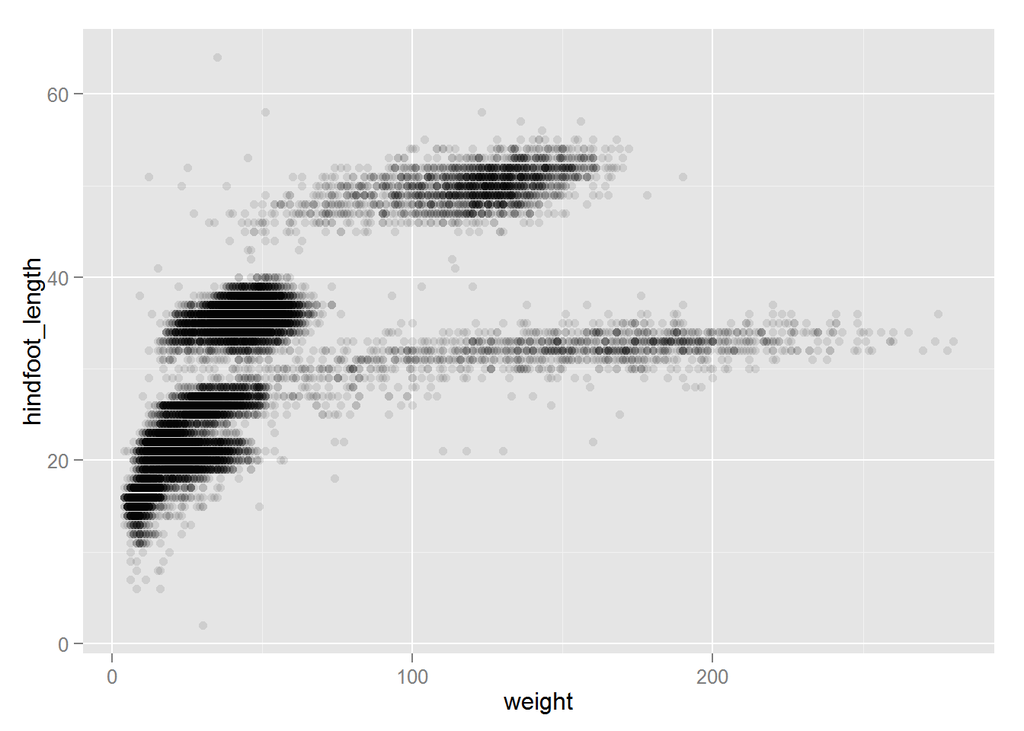

```r
ggplot(surveys_complete, aes(x = weight, y = hindfoot_length)) +
  geom_point(alpha=0.1)
```

- adding colors

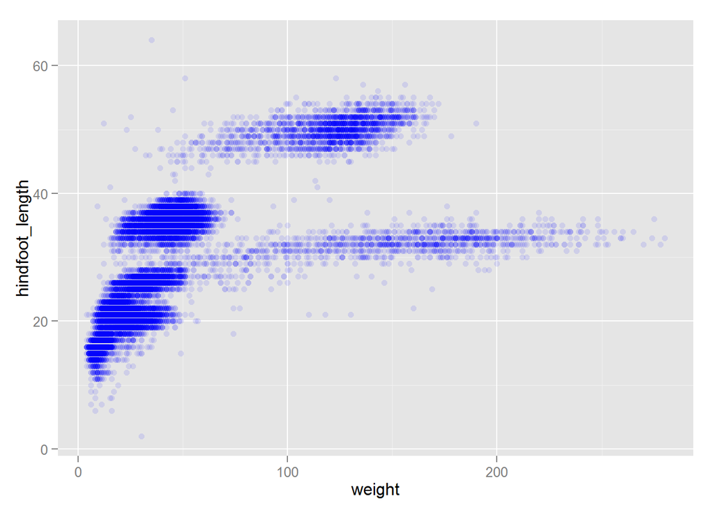

```r
ggplot(surveys_complete, aes(x = weight, y = hindfoot_length)) +
  geom_point(alpha=0.1, color="blue")
```

## Boxplot

Visualising the distribution of weight within each species.

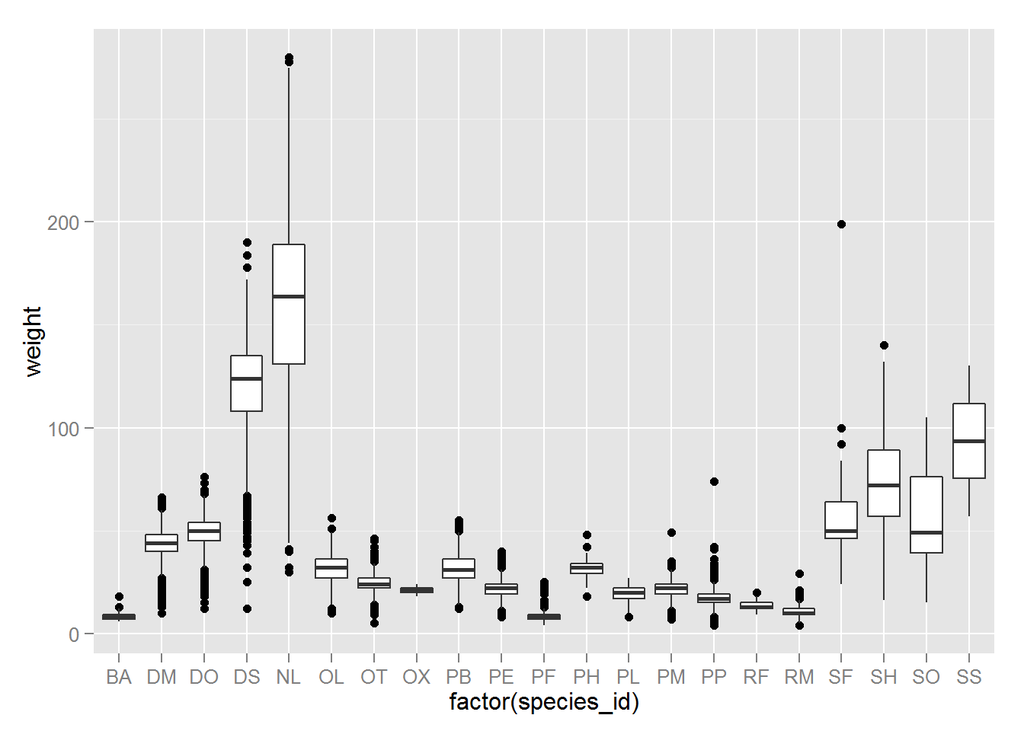

```r
ggplot(surveys_weight_present, aes(factor(species_id), weight)) +
                   geom_boxplot()
```

By adding points to boxplot, we can see particular measurements and the abundance of measurements.

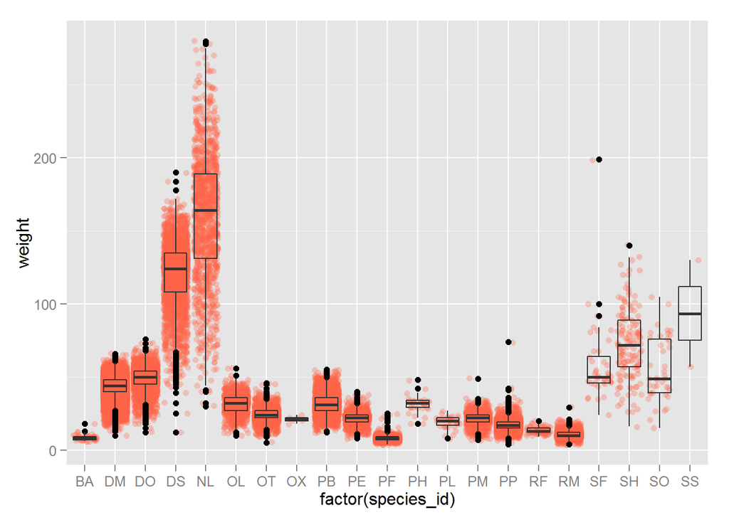

```r
ggplot(surveys_weight_present, aes(factor(species_id), weight)) +
                   geom_jitter(alpha=0.3, color="tomato") +
                   geom_boxplot(alpha=0)
```

### Challenge

> Create boxplot for `hindfoot_length`.

## Plotting time series data

Let’s calculate number of counts per year for each species. To do that we need to group data first and count records within each group.

```r
yearly_counts <- surveys %>%
                 group_by(year, species_id) %>%
                 tally
```

Timelapse data can be visualised as a line plot with years on x axis and counts on y axis.

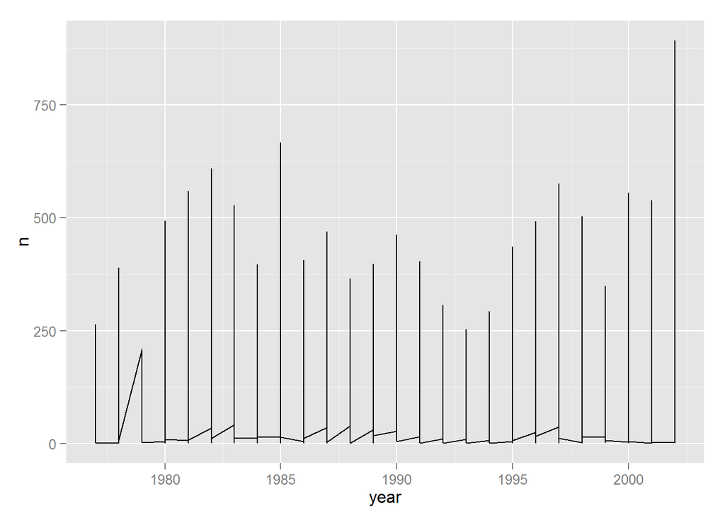

```r
ggplot(yearly_counts, aes(x=year, y=n)) +
                  geom_line()
```

Unfortunately this does not work, because we plot data for all the species together. We need to tell ggplot to split graphed data by `species_id`

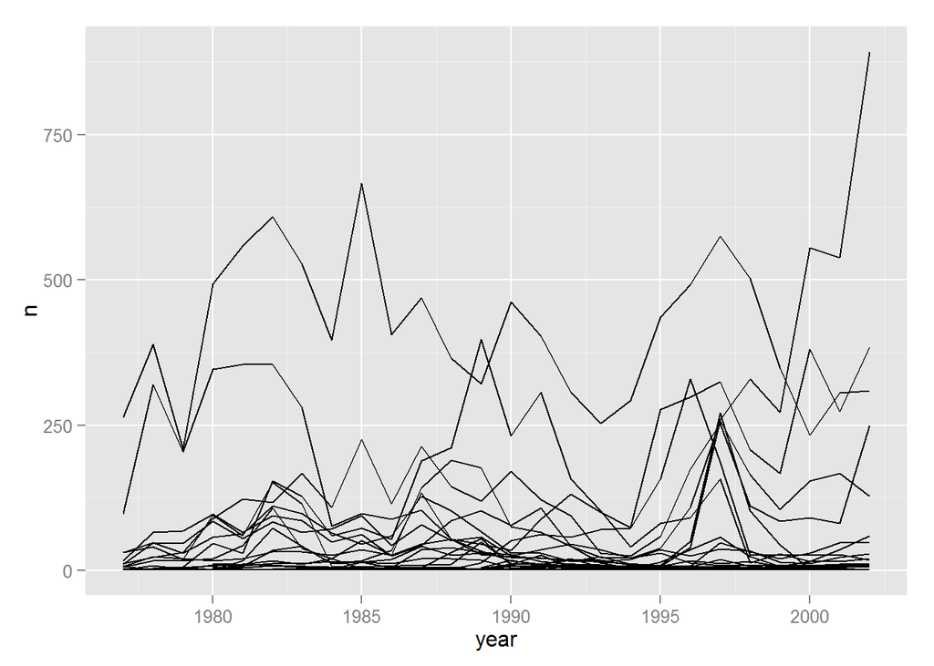

```r
ggplot(yearly_counts, aes(x=year, y=n, group=species_id)) +
  geom_line()
```

We will be able to distiguish species in the plot if we add colors.

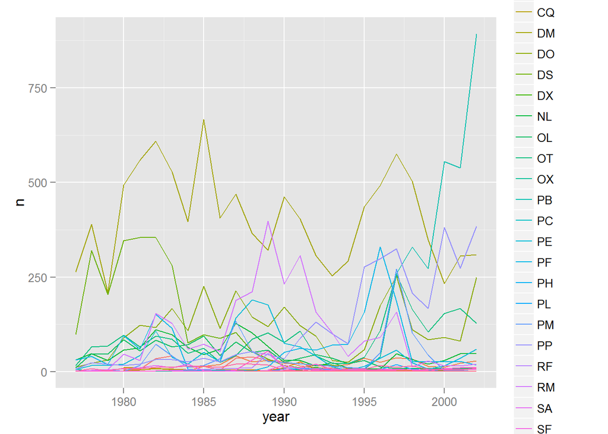

```r
ggplot(yearly_counts, aes(x=year, y=n, group=species_id, color=species_id)) +
  geom_line()
```

## Faceting

ggplot has a special technique called *faceting* that allows to split one plot into mutliple plots based on some factor. We will use it to plot one time series for each species separately.

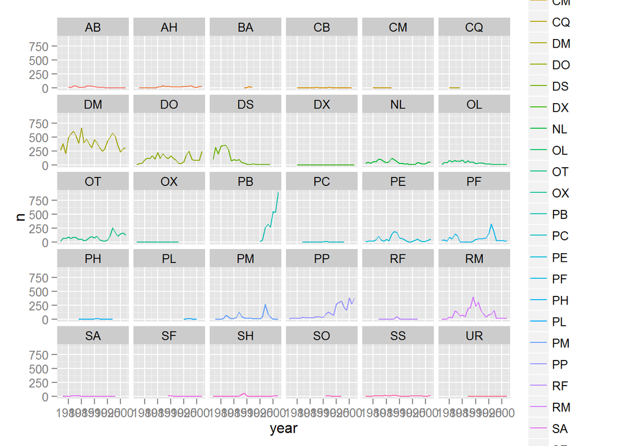

```r
ggplot(yearly_counts, aes(x=year, y=n, color=species_id)) +
  geom_line() + facet_wrap(~species_id)
```

Now we wuld like to split line in each plot by sex of each individual measured. To do that we need to make counts in dataframe grouped by sex.

### Challenges:

> - filter the dataframe so that we only keep records with sex “F” or “M”s

```r
sex_values = c("F", "M")
surveys <- surveys %>%
           filter(sex %in% sex_values)
```

> - group by year, species_id, sex

```r
yearly_sex_counts <- surveys %>%
                     group_by(year, species_id, sex) %>%
                     tally
```

> - make the faceted plot spliting further by sex (within single plot)

```
#> geom_path: Each group consist of only one observation. Do you need to adjust the group aesthetic?
```

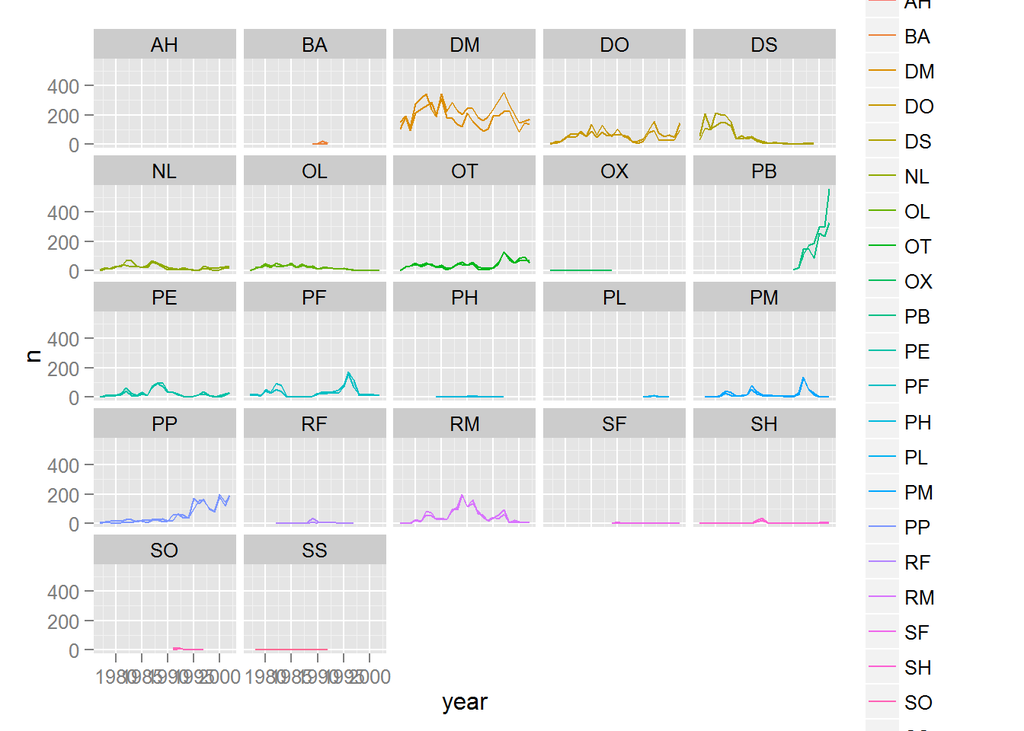

```r
ggplot(yearly_sex_counts, aes(x=year, y=n, color=species_id, group=sex)) +
  geom_line() + facet_wrap(~ species_id)
```

> We can improve the plot by coloring by sex instead of species (species are already in separate plots, so we don’t need to distinguish them better)

```
#> geom_path: Each group consist of only one observation. Do you need to adjust the group aesthetic?
```

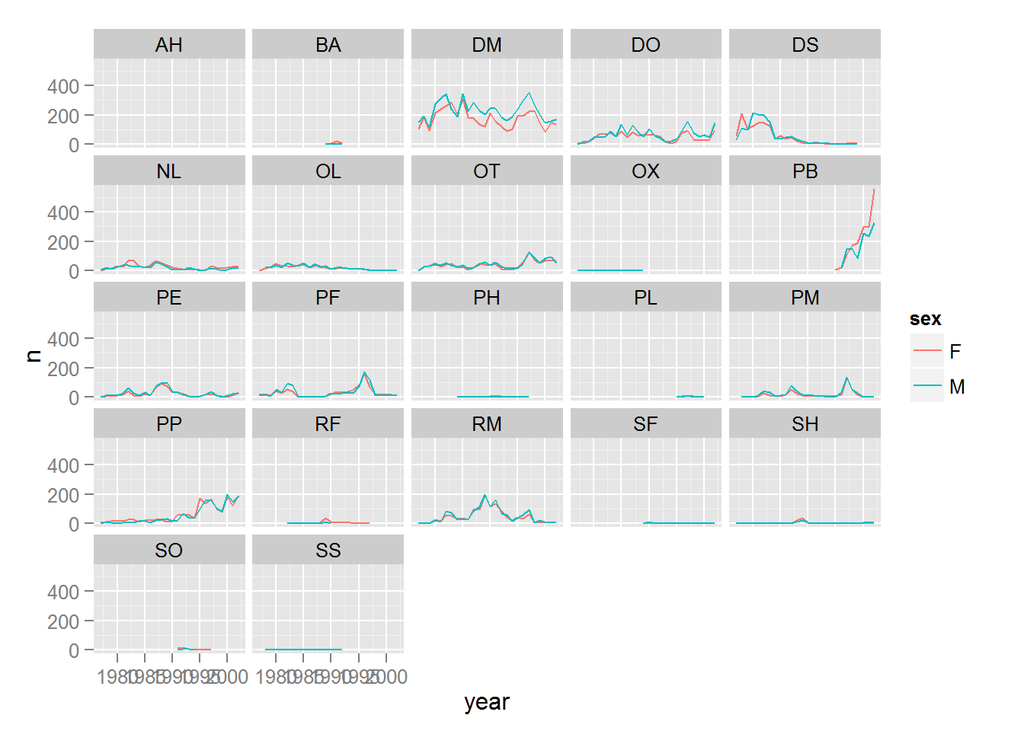

```r
ggplot(yearly_sex_counts, aes(x=year, y=n, color=sex, group=sex)) +
  geom_line() + facet_wrap(~ species_id)
```